# Class 01: Intro to Vector Data & sf Library

Author

Michael Fehl

Published

January 15, 2025

Bruno’s Office: 20.1E64 (by cafeteria)

# Intro

## Application Examples

- Cholera Maps in London
- Long-term Consequences of Mita (Colonial) System in Peru
  - Spatial discontinuity to find long-lasting development differences
- Transport Integration and Welfare in India
- Climate Change & Urbanization in Africa

## Data Sources

Comprehensive list of spatial data sources:

[output not shown]

# Vector Data: `sf`

`sf`: ‘Simple Feature’

Spatial Data is stored as **vector** form or **raster** form. We’ll focus on the **vector** format first

- *Vectors*
  - Spatial geometries: collection of pts/lines/polygons over a geography
  - Stored as a variable in a df: `st_sf`
  - Typical formats:
    - .shp (most common)
    - .json (geoJSON)
    - .gpk (geopackage)
    - .kmz (google earth)

## Basics

We have three basic geometries for our vector data: *points*, *lines*, & *polygons*

These geometries are stored as arrays: numeric vectors, matrices, & lists

### Shapes

#### 1. **Points**

Simplest form of geometry; typically translate to (LONG, LAT)

A single **POINT** is declared using the command `st_point`, by passing in a single numeric vector:

```r
# single point
geom_point <- c(2,4)
single_pt <- st_point(geom_point)
st_as_text(single_pt)
```

```
[1] "POINT (2 4)"
```

whilst a collection of points is known as **MULTIPOINT**, declared using the command `st_multipoint` command, which expects a numeric matrix (*specifically a 2D array*):

```r
# multiple points
geom_multipoints <- rbind(c(2,4), c(1,5), c(0,2), c(1,0))
multipts <- st_multipoint(geom_multipoints)
st_as_text(multipts)
```

```
[1] "MULTIPOINT ((2 4), (1 5), (0 2), (1 0))"
```

#### 2. **Lines**

Lines are simply a collection of points connected sequentially (meaning the ordering of our points matters!)

A single **LINESTRING** can be constructed from a 2D numeric array, the same exact way as a **MULTIPOINT**, only now using the command `st_linestring`:

```r
# single line
geom_multipoints <- rbind(c(2,4), c(1,5), c(0,2), c(1,0))
single_line <- st_linestring(geom_multipoints)
st_as_text(single_line)
```

```
[1] "LINESTRING (2 4, 1 5, 0 2, 1 0)"
```

We can also construct multiple linestrings, known as **MULTILINES** using the command `st_multilinestring`: expects a list of numeric matrices (2D arrays).

```r
# multiple lines
geom_multilines <- list(rbind(c(2,4), c(1,5), c(0,2), c(1,0)),
                        rbind(c(0,0), c(1,1), c(2,2), c(3,3)),
                        rbind(c(1,1), c(1,0), c(1,-1)))
multi_lines <- st_multilinestring(geom_multilines)
st_as_text(multi_lines)
```

```
[1] "MULTILINESTRING ((2 4, 1 5, 0 2, 1 0), (0 0, 1 1, 2 2, 3 3), (1 1, 1 0, 1 -1))"
```

#### 3. **Polygons**

Finally, we can create shapes by building lines as we did before, but now making sure the first point & last point are the same. Polygons require a list of numeric array(s)

A single **POLYGON** follows the same logic as **MULTILINES**, now with the same coordinates for the first and last points. We use now the command `st_polygon` to build this object:

```r
# single line
geom_singlepoly <- list(rbind(c(2,4), c(1,5), c(0,2), c(1,0), c(2,4)))
single_poly <- st_polygon(geom_singlepoly)
st_as_text(single_poly)
```

```
[1] "POLYGON ((2 4, 1 5, 0 2, 1 0, 2 4))"
```

We can, like before with lines, build & assign multiple **POLYGONS** to a single object, aptly named a **MULTIPOLYGON**. The difference for this is that we must input a list of lists; i.e. a list of single polygons, using the command `st_multipolygon`

```r
# single line
geom_multipoly <- list(list(rbind(c(3,4), c(3,3), c(5,3), c(5,4), c(3,4))), # rectangle
                        list(rbind(c(1,4), c(1,5), c(2,4), c(1,4)))) # right triangle
multi_poly <- st_multipolygon(geom_multipoly)
st_as_text(multi_poly)
```

```
[1] "MULTIPOLYGON (((3 4, 3 3, 5 3, 5 4, 3 4)), ((1 4, 1 5, 2 4, 1 4)))"
```

### Simple Features (sf)

SIMPLE FEATURE:

- SF COLUMN (GEOMETRY + PROJECTION) +
- ATTRIBUTE (DATA FRAME)

## **Example 1**: spatial geometries

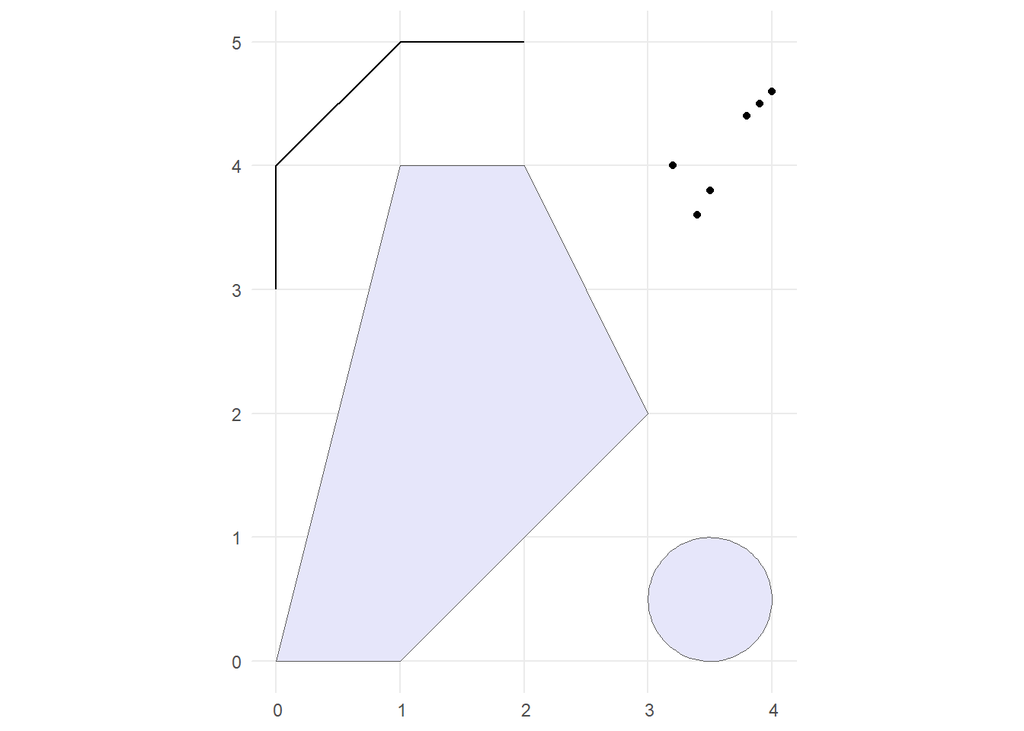

```r
# multipoint (think: long-lat)
multipt_matrix <- rbind(c(3.2, 4), c( 4, 4.6), c(3.8, 4.4),
                           c(3.5, 3.8), c(3.4, 3.6), c(3.9, 4.5))
gm.multipt <- st_multipoint(multipt_matrix)

# linestring (connecting pts; order matters)
linestring_matrix <- rbind(c(0, 3), c(0,4), c(1,5), c(2,5))
gm.linestr <- st_linestring(linestring_matrix)

# polygon (last pt & first pt must match)
angle <- seq(0, 2*pi, length.out = 100)
circle_coords <- cbind(3.5 + 0.5*cos(angle), 0.5 + 0.5*sin(angle))
polygon_matrix <- list(list(rbind(c(0,0), c(1,0), c(3,2), c(2,4), c(1,4), c(0,0))),
                       list(rbind(circle_coords, circle_coords[1,])))
gm.poly <- st_multipolygon(polygon_matrix)

# create these objects into a column: st_sfc
geom <- st_sfc(gm.multipt, gm.linestr, gm.poly)

# our normal (non-geom) dataframe
mock_data <- data.frame(objects = c('multipt', 'linestr', 'polyg'))

# append our geom data to our data_frame, declare it as a sf object
sf_mockdata <- st_sf(mock_data, geometry = geom)

# plot our shapes!
ggplot() +
  geom_sf(data=sf_mockdata, fill = "lavender") +
  theme_minimal()
```

### Projections

The world is a 3D object: when we try to project this onto a 2D surface (like a map), it is impossible to not have distortion (proven by Gauss, known as the “Theorema Egregium” – [reference](https://en.wikipedia.org/wiki/Theorema_Egregium) for a deeper dive into the math).

The basic idea behind the differential geometry is that a (2D) plane has $K=0$ Gaussian curvature, whilst a (3D) sphere w/ radius ‘R’ has a constant & strictly positive curvature, $K=\frac{1}{R^2}$. There does not exist a function to perfectly map the plane to the sphere (and vice versa); consequentially, every cartographic projection must contain at least some distortion between distances.

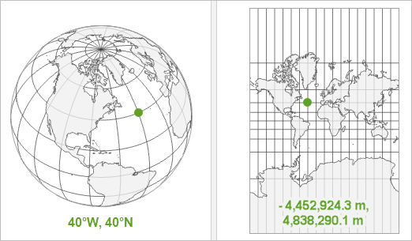

Map Projection Distortion

Thus, we need to pay attention to what sort of projection structure our data has. There exists a plethora of ways to project the globe onto a map; what is important is that these projections are both:

- well-defined, and
- standardized (agree in their projections)

Otherwise when we try to build our spatial models, we might end up at completely incorrect coordinates. The ‘standard’ (most common) longitude-latitude used is Geodetic CRS: WGS 84; passed as an argument as `crs = 'EPSG:4326'`. For example:

```r
gm.point <- st_point(c(11.3, 44.4)) # c(longitude,latitude)
gmc.point <- st_sfc(gm.point,
                    crs = 'EPSG:4326')
gmc.point; st_as_text(gmc.point)
```

```
Geometry set for 1 feature
Geometry type: POINT
Dimension:     XY
Bounding box:  xmin: 11.3 ymin: 44.4 xmax: 11.3 ymax: 44.4
Geodetic CRS:  WGS 84
```

```
[1] "POINT (11.3 44.4)"
```

What if we have an array (2D matrix) of multipoints that dont have a projection assigned to them? for example:

```r
df.cities <- data.frame(
  name = c('Bologna', 'London', 'Madrid', 'Paris'),
  temperature = c(31, 21, 29,28),
  language = c('Italian', 'English', 'Spanish', 'French'),
  longitude = c(11.3,-0.1,-3.7,2.3),
  latitude = c(44.4,51.5, 40.4,48.8)
)
# Declare the data frame as an sf object, & declare our 'coords' col as the geometry
sf.cities <- st_as_sf(df.cities,
                      coords = c('longitude', 'latitude'))
sf.cities # Missing CRS!
```

```
Simple feature collection with 4 features and 3 fields
Geometry type: POINT
Dimension:     XY
Bounding box:  xmin: -3.7 ymin: 40.4 xmax: 11.3 ymax: 51.5
CRS:           NA
     name temperature language          geometry
1 Bologna          31  Italian POINT (11.3 44.4)
2  London          21  English POINT (-0.1 51.5)
3  Madrid          29  Spanish POINT (-3.7 40.4)
4   Paris          28   French  POINT (2.3 48.8)
```

Notice the output for CRS: `NA` – it is important to specify and/or standardize!

```r
# Correct version
sf.cities <- st_as_sf(
  df.cities,
  coords = c('longitude', 'latitude'),
  crs = 'EPSG:4326'
  )

sf.cities
```

```
Simple feature collection with 4 features and 3 fields
Geometry type: POINT
Dimension:     XY
Bounding box:  xmin: -3.7 ymin: 40.4 xmax: 11.3 ymax: 51.5
Geodetic CRS:  WGS 84
     name temperature language          geometry
1 Bologna          31  Italian POINT (11.3 44.4)
2  London          21  English POINT (-0.1 51.5)
3  Madrid          29  Spanish POINT (-3.7 40.4)
4   Paris          28   French  POINT (2.3 48.8)
```

## **Example 2**: Airports

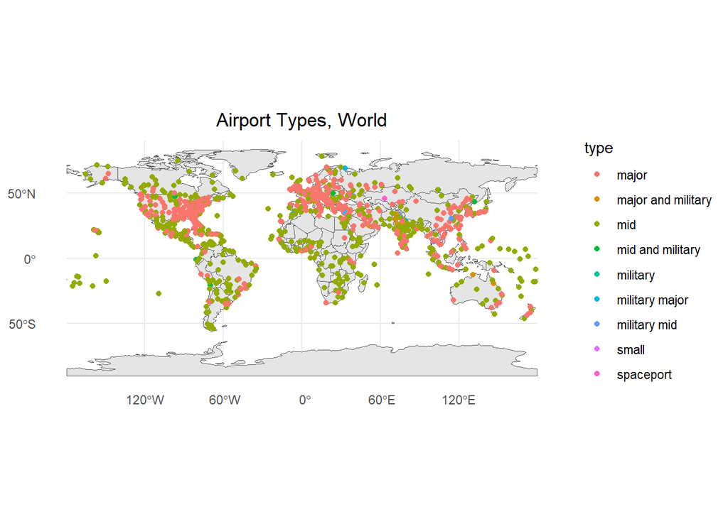

```r
airports <- st_read("ne_10m_airports/ne_10m_airports.shp")

gmsf.world <- world # empty world map

ggplot() +
  geom_sf(data=gmsf.world) +
  geom_sf(data=airports, aes(color=type)) +
  labs(title = "Airport Types, World") +
  theme_minimal() +
  theme(plot.title = element_text(hjust = 0.5))
```

### Saving our work

```r
# # export data as a csv file
# fwrite(x = df.merged,file = 'merged_dataset.csv', sep = '\t')
#
# ## bonus case: Stata Files
# # symbols in the column names. Replace them with '_':
# setnames(df.merged, gsub('\\.', '_',tolower(names(df.merged))))
# # Exporting it:
# write_dta(data = df.merged, path = 'merged_dataset.dta')
```

Back to top